# Práctica 7: Gráficos de variables estadísticas

> Alumno: Miguel Ángel Fernández Gutiérrez <mianfg@correo.ugr.es>

## Ejercicio 1

Previa inspección del fichero (desde por ejemplo el bloc de notas), carga los datos en R. Hazlo de modo que se almacenen en un objeto de tipo data frame, con nombre `employee`, en el que las variables `gender`, `jobcat` y `minority` se consideren como factores. Una vez almacenados renombra los niveles del factor `gender` como `female` y `male`.

```r
employee <- read.table('./data/Employee.txt', header=T, sep=' ', as.is=NA)
employee
```

| salary | age | edu | startsal | jobtime | prevexp | minority | gender | jobcat |
| --- | --- | --- | --- | --- | --- | --- | --- | --- |
| 57000 | 36 | 15 | 27000 | 98 | 144 | no_min | m | manager |
| 40200 | 30 | 16 | 18750 | 98 | 36 | no_min | m | clerical |
| 21450 | 59 | 12 | 12000 | 98 | 381 | no_min | f | clerical |
| 21900 | 41 | 8 | 13200 | 98 | 190 | no_min | f | clerical |
| 45000 | 33 | 15 | 21000 | 98 | 138 | no_min | m | clerical |
| 32100 | 30 | 15 | 13500 | 98 | 67 | no_min | m | clerical |
| 36000 | 32 | 15 | 18750 | 98 | 114 | no_min | m | clerical |
| 21900 | 22 | 12 | 9750 | 98 | 0 | no_min | f | clerical |
| 27900 | 42 | 15 | 12750 | 98 | 115 | no_min | f | clerical |
| 24000 | 42 | 12 | 13500 | 98 | 244 | no_min | f | clerical |

[output cut: 463 more lines]

```r
levels(employee$gender) <- c("female", "male")
employee
```

| salary | age | edu | startsal | jobtime | prevexp | minority | gender | jobcat |
| --- | --- | --- | --- | --- | --- | --- | --- | --- |
| 57000 | 36 | 15 | 27000 | 98 | 144 | no_min | male | manager |
| 40200 | 30 | 16 | 18750 | 98 | 36 | no_min | male | clerical |
| 21450 | 59 | 12 | 12000 | 98 | 381 | no_min | female | clerical |
| 21900 | 41 | 8 | 13200 | 98 | 190 | no_min | female | clerical |
| 45000 | 33 | 15 | 21000 | 98 | 138 | no_min | male | clerical |
| 32100 | 30 | 15 | 13500 | 98 | 67 | no_min | male | clerical |
| 36000 | 32 | 15 | 18750 | 98 | 114 | no_min | male | clerical |
| 21900 | 22 | 12 | 9750 | 98 | 0 | no_min | female | clerical |
| 27900 | 42 | 15 | 12750 | 98 | 115 | no_min | female | clerical |
| 24000 | 42 | 12 | 13500 | 98 | 244 | no_min | female | clerical |

[output cut: 463 more lines]

## Ejercicio 2

Sobre gráfico anterior dibuja también la función de densidad de una Normal cuya media y desviación típica sean las de los datos de `salary`. ¿Te parece que este podría ser un buen modelo de probabilidad para describir estos datos?

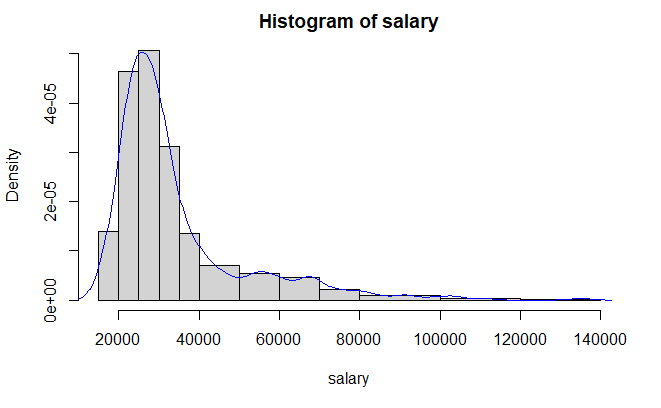

```r
attach(employee)
x1 <-seq(15000,40000,by=5000)
x2 <-seq(50000,80000,by=10000)
x3 <-seq(100000,140000,by=20000)
hist(salary,breaks=c(x1,x2,x3))
lines(density(salary),col='blue')
```

```r
hist(salary,breaks=c(x1,x2,x3))
lines(density(salary),col='blue')
```

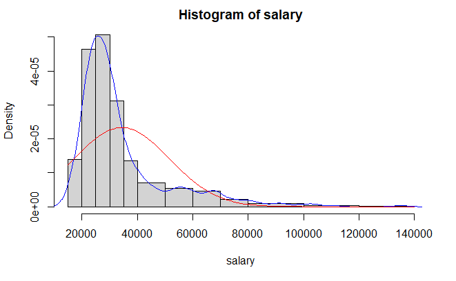

```r
curve(dnorm(x,mean=mean(salary),sd=sd(salary)),add=T,col='red')
```

Vemos que no se trata de un buen ajuste

## Ejercicio 3

Realiza un análisis similar con las variables `startsal` y `age`.

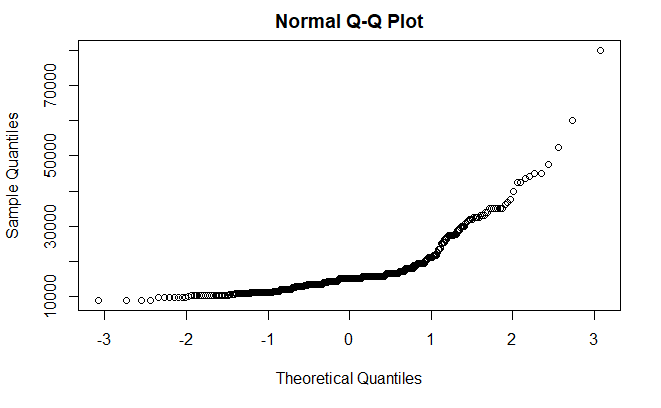

```r
qqnorm(startsal)
```

```r
ks.test(startsal,pnorm,mean=mean(startsal),sd=sd(startsal))
```

```
    One-sample Kolmogorov-Smirnov test

data:  startsal
D = 0.25304, p-value < 2.2e-16
alternative hypothesis: two-sided
```

```r
shapiro.test(startsal)
```

```
    Shapiro-Wilk normality test

data:  startsal
W = 0.71445, p-value < 2.2e-16
```

Vemos que tampoco sigue una normal.

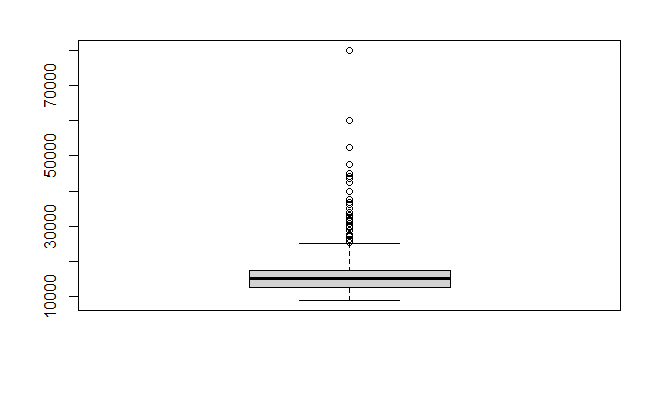

```r
boxplot(startsal)
```

```r
hist(startsal,probability=TRUE,main="",axes=FALSE)
axis(1)
```

```r
lines(density(startsal),col='red',lwd=2)
par(new=TRUE)
```

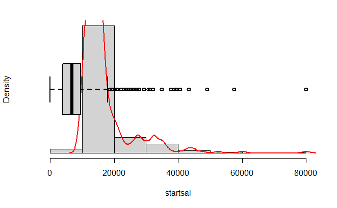

```r
boxplot(startsal,horizontal=TRUE, axes=FALSE,lwd=2)
```

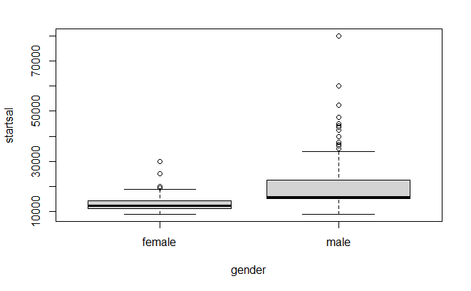

```r
boxplot(startsal~gender)
```

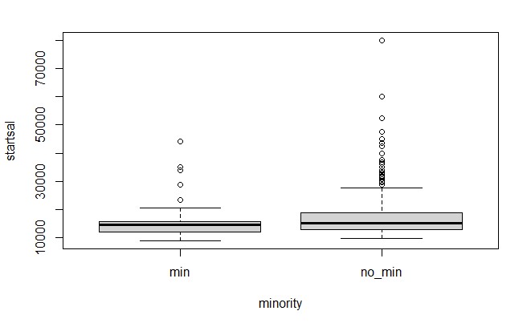

```r
boxplot(startsal~minority)
```

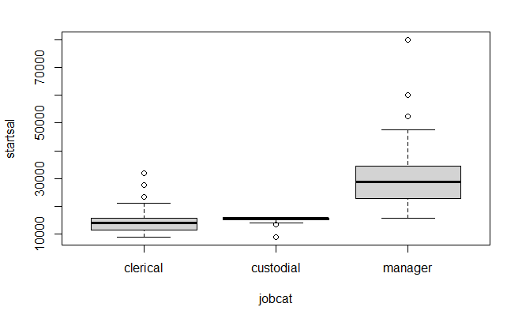

```r
boxplot(startsal~jobcat)
```

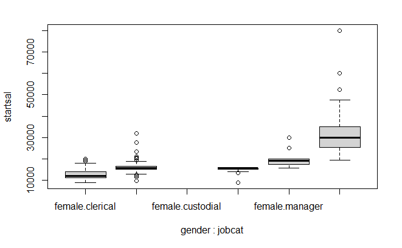

```r
boxplot(startsal~gender*jobcat)
```

Vemos un comportamiento muy similar a `salary`.

## Ejercicio 4

Realiza un estudio similar que permita descubrir una posible relación entre: (i) las variables `salary` y `age`; y (ii) las variables `salary` y `edu`. ¿Qué puedes interpretar de los gráficos?

### i) `salary` y `age`

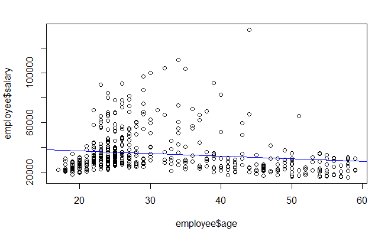

```r
mod <- lm(employee$salary~employee$age)
plot(employee$age,employee$salary)
abline(mod,col='blue')
```

### ii) `salary` y `edu`

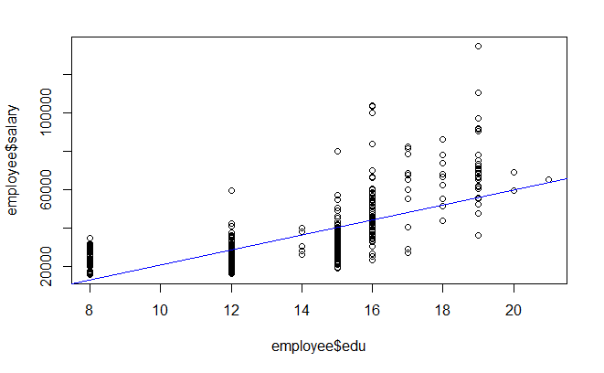

```r
mod <- lm(employee$salary~employee$edu)
plot(employee$edu, employee$salary)
abline(mod, col='blue')
```

## Ejercicio 5

Realiza un análisis similar para los otros dos factores (`gender` y `minority`).

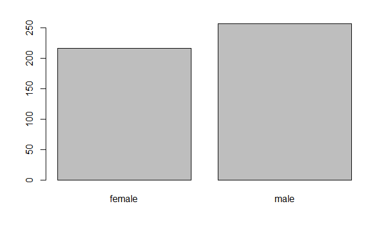

```r
tab<-table(gender)
tab.fi<-prop.table(tab)
barplot(tab)
```

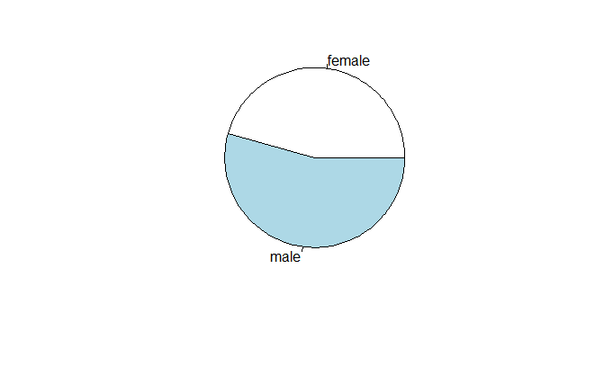

```r
pie(tab)
```

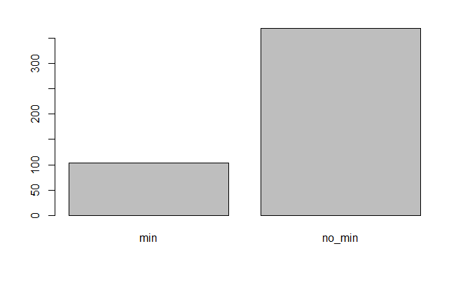

```r
tab<-table(minority)
tab.fi<-prop.table(tab)
barplot(tab)
```

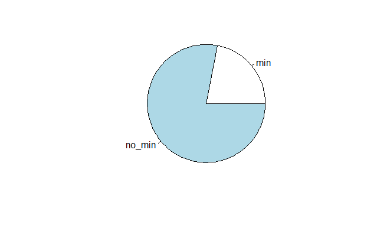

```r
pie(tab)
```

## Ejercicio 6

Construye una tabla de contingencia que muestre la clasificación de los individuos según `jobcat` y `minority`. Representa un diagrama de barras que muestre dicha clasificación.

```r
tab2<-table(employee$jobcat,employee$minority)
addmargins(tab2); tab2
```

```
            min no_min Sum
  clerical   87    275 362
  custodial  13     14  27
  manager     4     80  84
  Sum       104    369 473

            min no_min
  clerical   87    275
  custodial  13     14
  manager     4     80
```

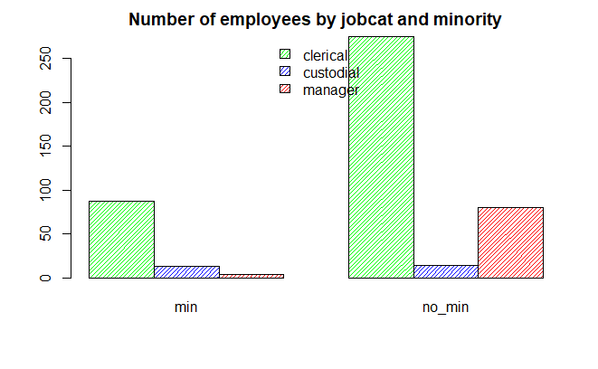

```r
barplot(tab2,legend.text=TRUE, args.legend=list(x='top',bty='n'), density=30,col=c('green','blue','red'), main='Number of employees by jobcat and minority', beside=TRUE)
```

## Ejercicio propuesto

### Ejercicio 1

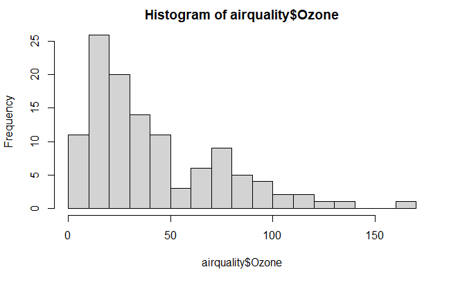

```r
hist(airquality$Ozone, breaks=seq(from=0, by=10, length.out=18))
```

### Ejercicio 2

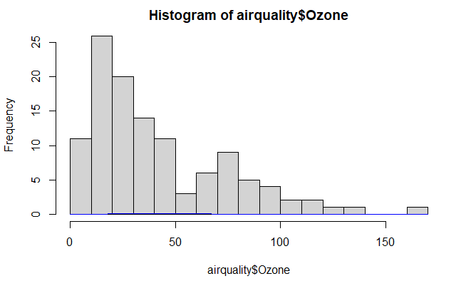

```r
hist(airquality$Ozone, breaks=seq(from=0, by=10, length.out=18))
curve(dnorm(x,mean=mean(airquality$Ozone, na.rm=TRUE), sd=sd(airquality$Ozone, na.rm=TRUE)), add=TRUE, col='blue')
```

No tenemos un buen modelo

### Ejercicio 3

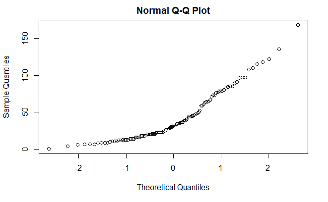

```r
qqnorm(airquality$Ozone)
```

No sigue una distribución normal, de primeras. El siguiente test nos lo confirma:

```r
shapiro.test(airquality$Ozone)
```

```
    Shapiro-Wilk normality test

data:  airquality$Ozone
W = 0.87867, p-value = 2.79e-08
```

### Ejercicio 4

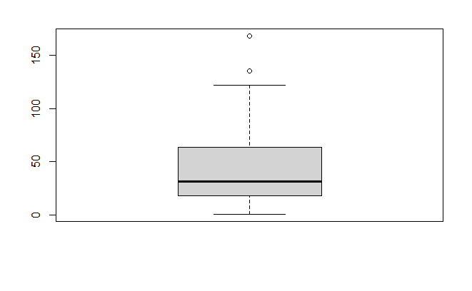

```r
boxplot(airquality$Ozone)
```

El boxplot nos indica que los datos están dispersos, especialmente en los niveles más altos de ozono (vemos que el cuartil 4 está más lejano de la mediana que el otro).

### Ejercicio 5

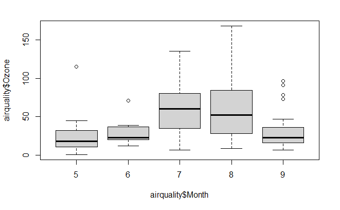

```r
boxplot(airquality$Ozone~airquality$Month)
```

Vemos que las dispersiones varían significativamente dependiendo del mes. También vemos cuándo hay más y menos contaminación: en verano es cuando hay más ozono.

### Ejercicio 6

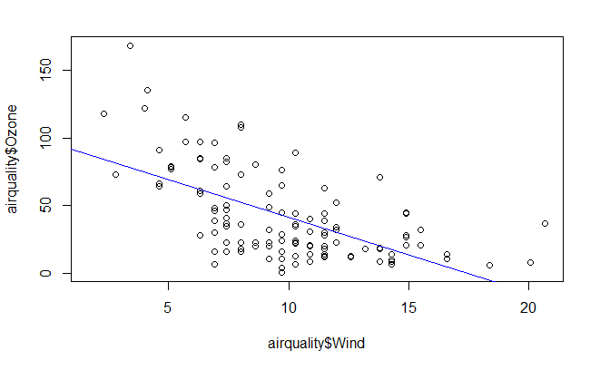

```r
mod <- lm(airquality$Ozone~airquality$Wind)
plot(airquality$Wind,airquality$Ozone)
abline(mod,col='blue')
```

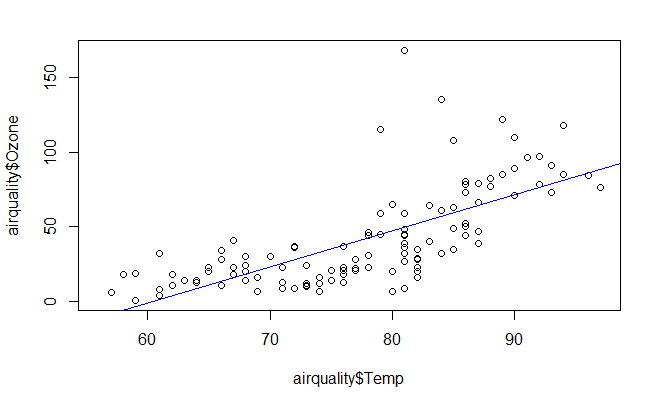

```r
mod <- lm(airquality$Ozone~airquality$Temp)
plot(airquality$Temp,airquality$Ozone)
abline(mod,col='blue')
```

Vemos que hay un ajuste medianamente bueno en ambos casos. Veamos cuál es mejor:

```r
summary(lm(airquality$Ozone~airquality$Wind))$r.squared
```

```
[1] 0.3618582
```

```r
summary(lm(airquality$Ozone~airquality$Temp))$r.squared
```

```
[1] 0.4877072
```